# The Linear Model

Now we branch into three important problems: the classification problem that we have seen and two other important problems called regression and probability estimation. The three problems come with different but related algorithms, and cover a lot of territory in learning from data.

## Linear Classification

The linear model for classifying data into two classes uses a hypothesis set of linear classifiers, where each $h$ has the form

$$ h(\boldsymbol{x}) = sign(\boldsymbol{w}^T \boldsymbol{x}) $$

for some column vector $\boldsymbol{w} \in \mathbb{R}^{d+1}$, where $d$ is the dimensionality of the input space, and the added coordinate $x_0 = 1$ corresponds to the bias "weight" $w_0$.

Before we introduced the perceptron learning algorithm (PLA),but the algorithm convergence is only guaranteed when the data is linearly separable.

### Non-Separable Data

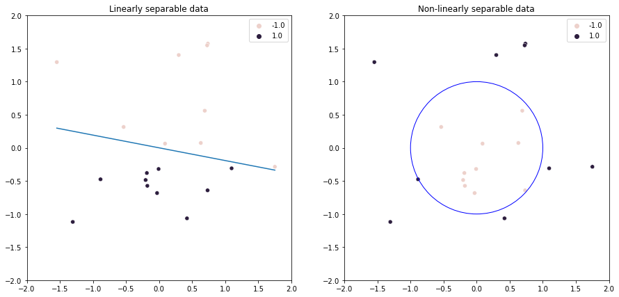

```python
figure
```

The previous situation is actually encountered very often: even though a linear classifier seems appropriate, the data may not be linearly separable because of outliers or noise. To find a hypothesis with the minimum $E_{in}$, we need to solve the combinatorial optimization problem:

$$ \min_{\boldsymbol{w} \in \mathbb{R}^{d+1}} E_{in}( \boldsymbol{w}) = \min_{\boldsymbol{w} \in \mathbb{R}^{d+1}} \frac{1}{N} \sum_{n=1}^{N} [\![ sign(\boldsymbol{w}^T \boldsymbol{x}_n) \neq y_n ]\!] $$

The difficulty in solving this problem arises from the discrete nature of both $sign(\cdot)$ and $[\![ \cdot ]\!]$.

One approach for getting an approximate solution is to extend PLA through a simple modification into what is called the pocket algorithm. Essentially, the pocket algorithm keeps "in its pocket" the best weight vector encountered up to iteration $t$ in PLA. At the end, the best weight vector will be reported as the final hypothesis.

#### The Pocket Algorithm

1. Set the pocket weight vector $\hat{\boldsymbol{w}}$ to $\boldsymbol{w}(0)$ of PLA.
2. For $t=0,\cdots, T-1$ do
   1. Run PLA for one update to obtain $\boldsymbol{w}(t + 1)$.
   2. Evaluate $E_{in}( \boldsymbol{w}(t + 1) )$.
   3. If $\boldsymbol{w}(t + 1)$ is better than $\hat{\boldsymbol{w}}$ in terms of $E_{in}$, set $\hat{\boldsymbol{w}}$ to $\boldsymbol{w}(t+1)$.
3. Return $\hat{\boldsymbol{w}}$.

## Linear Regression

Linear regression is another useful linear model that applies to real-valued target functions.

Regression, a term inherited from earlier work in statistics, means y is real valued.

Let us revisit our application in credit approval, this time considering a regression problem rather than a classification problem. Instead of just making a binary decision (approve or not), the bank also wants to set a proper credit limit for each approved customer. This is a regression learning problem. The bank uses historical records to construct a data set $\mathcal{D}$ of examples $(\boldsymbol{x}_1 , y_1), (\boldsymbol{x}_2 , y_2 ) , . . . , (\boldsymbol{x}_N , y_N)$, where $\boldsymbol{x}_n$ is customer information and $y_n$ is the credit limit set by one of the human experts in the bank.

### The Algorithm

The linear regression algorithm is based on minimizing the squared error between $h(\boldsymbol{x})$ and $y$.

$$ E_{out}(h) = \mathbb{E} \left[ (h(\boldsymbol{x}) - y)^2 \right] $$

where the expected value is taken with respect to the joint probability distribution $P(\boldsymbol{x}, y)$. The goal is to find a hypothesis that achieves a small $E_{out}(h)$. Since the distribution $P(\boldsymbol{x}, y)$ is unknown, $E_{out}(h)$ cannot be computed. Similar to what we did in classification, we resort to the in-sample version instead.

$$ E_{in}( h ) = \frac{1}{N} \sum_{n=1}^{N} ( h(\boldsymbol{x}_n) - y_n )^2 $$

In linear regression, $h$ takes the form of a linear combination of the components of $\boldsymbol{x}$. That is,

$$ h(\boldsymbol{x}) = \sum_{i=0}^d w_i x_i = \boldsymbol{w}^T \boldsymbol{x} $$

Then

$$ E_{in}( \boldsymbol{w} ) = \frac{1}{N} \sum_{n=1}^{N} ( \boldsymbol{w}^T \boldsymbol{x}_n - y_n )^2 = \frac{1}{N} || X \boldsymbol{w} - \boldsymbol{y}||^2 = \frac{1}{N} (\boldsymbol{w}^T X^T X \boldsymbol{w} - 2 \boldsymbol{w}^T X^T \boldsymbol{y} + \boldsymbol{y}^T \boldsymbol{y}) $$

Finally, the linear regression algorithm is formalized by the following optimization problem:

$$ \boldsymbol{w}_{lin} = arg \min_{\boldsymbol{w} \in \mathbb{R}^{d+1}} E_{in} (\boldsymbol{w}) $$

**Excersise**

The gradient is a ( column ) vector whose $i$-th component is $[ \nabla E_{in} ( \boldsymbol{w} ) ]_i=\frac{\partial}{\partial w_i} E_{in}(\boldsymbol{w})$. By explicity computing $\frac{\partial}{\partial w_i}$, verify the following identities.

- $\nabla_{\boldsymbol{w}} (\boldsymbol{w}^T A \boldsymbol{w}) = (A + A^T)\boldsymbol{w}$
- $\nabla_{\boldsymbol{w}} (\boldsymbol{w}^T \boldsymbol{b}) = \boldsymbol{b}$

To optimize the problem we compute the gradient and set to zero vector

$$ \nabla_{\boldsymbol{w}} E_{in} (\boldsymbol{w}) = \boldsymbol{0} $$

Once computed we obtain

$$ \nabla_{\boldsymbol{w}} E_{in} (\boldsymbol{w}) = \frac{2}{N}(X^T X \boldsymbol{w} - X^T \boldsymbol{y}) = \boldsymbol{0} $$

Then

$$ X^T X \boldsymbol{w} = X^T \boldsymbol{y} $$

If $X^T X$ is invertible, $\boldsymbol{w}=X^{\dagger}\boldsymbol{y}$ where $X^{\dagger}=(X^T X)^{-1} X^T$ is the *pseudo-inverse* of X. If $X^T X$ is not invertible, a pseudo-inverse can still be defined, but the solution will not be unique. In practice, $X^T X$ is invertible in most of the cases.

### Linear Regression Algorithm (Ordinary Least Squares)

1. Construct the matrix $X$ and the vector $\boldsymbol{y}$ from the data set $(\boldsymbol{x}_1, y_1), \cdots, (\boldsymbol{x}_N, y_N)$, where each $\boldsymbol{x}$ includes the $x_0=1$ bias coordinate, as follows

$$ X = \begin{bmatrix} \text{---} & \boldsymbol{x}_1^T & \text{---} \\ \text{---} & \boldsymbol{x}_2^T & \text{---} \\ & \vdots & \\ \text{---} & \boldsymbol{x}_N^T & \text{---} \end{bmatrix}, \;\;\; \boldsymbol{y} = \begin{bmatrix} y_1 \\ y_2 \\ \vdots \\ y_N \end{bmatrix} $$

1. Compute the pseudo-inverse $X^{\dagger}$ of the matrix $X$. If $X^T X$ is invertible,

$$ X^{\dagger} = (X^T X)^{-1} X^T $$

1. Return $\boldsymbol{w}_{lin} = X^{\dagger} \boldsymbol{y}$

## Logistic Regression

In linear regression, the signal itself is taken as the output, which is appropriate if you are trying to predict a real response that could be unbounded. In linear classification, the signal is thresholded at zero to produce a $\pm 1$ output, appropriate for binary decisions. A third possibility, which has wide application in practice, is to output a probability, a value between 0 and 1. Our new model is called logistic regression. It has similarities to both previous models, as the output is real ( like regression ) but bounded ( like classification ) .

In this new model, we need something in between these two cases that smoothly restricts the output to the probability range $[0, 1]$. One choice that accomplishes this goal is the logistic regression model,

$$ h(\boldsymbol{x}) = \theta(\boldsymbol{w}^T \boldsymbol{x}) $$

where $\theta$ is the so-called logistic function (or sigmoid function)

$$ \theta(s) = \frac{e^s}{1+e^s} $$

whose output is between 0 and 1. The output can be interpreted as a probability for a binary event. Linear classification also deals with a binary event, but the difference is that the "classification" in logistic regression is allowed to be uncertain, with intermediate values between 0 and 1 reflecting this uncertainty.

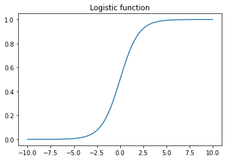

```python
ax.figure
```

In this case, the target is a probability that depends on the input $\boldsymbol{x}$. Formally, we are trying to learn the target function

$$ f(\boldsymbol{x}) = Pr[y=+1 | \boldsymbol{x}] $$

The data does not give us the value of explicitly. Rather, it gives us samples generated by this probability. Therefore, the data is in fact generated by a noisy target $P(y|\boldsymbol{x})$

$$ P(y|\boldsymbol{x}) = \begin{cases} f(\boldsymbol{x}) & \text{for }y=+1 \\ 1-f(\boldsymbol{x}) & \text{for }y=-1 \end{cases} $$

To learn from such data, we need to define a proper error measure that gauges how close a given hypothesis $h$ is to in terms of these noisy $\pm 1$ examples.

The standard error measure $e(h(\boldsymbol{x}), y)$ used in logistic regression is based on the notion of likelihood; how "likely" is it that we would get this output $y$ from the input $\boldsymbol{x}$ if the target distribution $P(y|\boldsymbol{x})$ was indeed captured by our hypothesis $h(\boldsymbol{x})$? The likelihood would be

$$ P(y|\boldsymbol{x}) = \begin{cases} h(\boldsymbol{x}) & \text{for }y=+1 \\ 1-h(\boldsymbol{x}) & \text{for }y=-1 \end{cases} $$

We substitute for $h(\boldsymbol{x})$ by its value $\theta(\boldsymbol{w}^T \boldsymbol{x})$, and use the fact that $1 - \theta(s) = \theta(-s)$ to get

$$ P(y|\boldsymbol{x}) = \theta(y \boldsymbol{w}^T \boldsymbol{x}) $$

Since the data points $(\boldsymbol{x}_1 , y_1), \cdots, (\boldsymbol{x}_N, y_N)$ are independently generated, the probability of getting all the $y_n$'s in the data set from the corresponding $\boldsymbol{x}_n$'s would be the product

$$ \prod_{n=1}^N P(y_n| \boldsymbol{x}_n) $$

The method of *maximum likelihood* selects the hypothesis $h$ which maximizes this probability. We can equivalently minimize a more convenient quantity,

$$ -\frac{1}{N} ln\left( \prod_{n=1}^N P(y_n| \boldsymbol{x}_n) \right) = \frac{1}{N} \sum_{n=1}^N ln\left(\frac{1}{P(y_n| \boldsymbol{x}_n)} \right) $$

since $-\frac{1}{N} ln(\cdot)$ is a monotonically decreasing function, we would be minimizing

$$ \frac{1}{N} \sum_{n=1}^N ln\left(\frac{1}{\theta(y_n \boldsymbol{w}^T \boldsymbol{x}_n)} \right) $$

with respect to the weight vector $\boldsymbol{w}$. The fact that we are minimizing this quantity allows us to treat it as an "error measure".

Substituting the functional form for $\theta(y_n \boldsymbol{w}^T \boldsymbol{x}_n)$ produces the in-sample error measure for logistic regression

$$ E_{in}(\boldsymbol{w}) = \frac{i}{N} \sum_{n=1}^{N} ln\left( 1+e^{-y_n \boldsymbol{w}^T \boldsymbol{x}_n} \right) $$

To train logistic regression, we will take an approach similar to linear regression in that we will try to set $\nabla E_{in}(\boldsymbol{w}) = \boldsymbol{0}$. Unfortunately, unlike the case of linear regression, the mathematical form of the gradient of $E_{in}$ for logistic regression is not easy to manipulate, so an analytic solution is not feasible.

### Gradient Descent

Gradient descent is a general technique for minimizing a twice-differentiable function, such as $E_{in}(\boldsymbol{w})$ in logistic regression.

A useful physical analogy of gradient descent is a ball rolling down a hilly surface. If the ball is placed on a hill, it will roll down, coming to rest at the bottom of a valley.

Let's now determine how to "roll" down the $E_{in}$-surface.

We would like to take a step in the direction of steepest descent, to gain the biggest bang for our buck. Suppose that we take a small step of size $\alpha$ in the direction of a unit vector $\boldsymbol{\hat{v}}$. The new weights are $\boldsymbol{w}(O) + \alpha \boldsymbol{\hat{v}}$. Since $\alpha$ is small, using the Taylor expansion to first order, we compute the change in $E_{in}$ as

$$ \Delta E_{in} = E_{in}(\boldsymbol{w}(0) + \alpha \boldsymbol{\hat{v}}) - E_{in}(\boldsymbol{w}(0)) \\ = \left[ E_{in}(\boldsymbol{w}(0)) + \alpha \nabla E_{in}(\boldsymbol{w}(0))^T \boldsymbol{\hat{v}} + O(\alpha^2)\right] - E_{in}(\boldsymbol{w}(0)) \\ = \alpha \nabla E_{in}(\boldsymbol{w}(0))^T \boldsymbol{\hat{v}} + O(\alpha^2) \\ \geq -\alpha ||\nabla E_{in}(\boldsymbol{w}(0))|| $$

Since $\boldsymbol{\hat{v}}$ is a unit vector, equality holds if and only if

$$ \boldsymbol{\hat{v}} = -\frac{\nabla E_{in}(\boldsymbol{w}(0))}{|| \nabla E_{in}(\boldsymbol{w}(0)) ||} $$

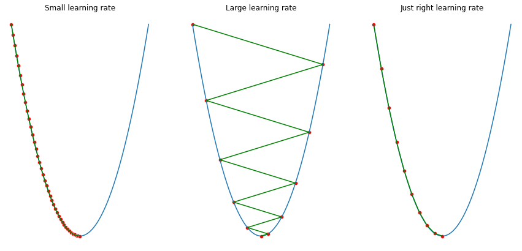

```python
figure
```

Ideally, we would like to take large steps when far from the minimum to get in the right ballpark quickly, and then small (more careful) steps when close to the minimum. A simple heuristic can accomplish this: far from the minimum, the norm of the gradient is typically large, and close to the minimum, it is small. Thus, we could set $\alpha_t = \alpha || \nabla E_{in}||$ to obtain the desired behavior for the variable step size, leading to the fixed learning rate gradient descent algorithm for minimizing $E_{in}$

**Fixed learning rate gradient descent**

1. Initialize the weights at time step $t=0$ to $\boldsymbol{w}(O)$.
2. For $t=0,1,2,\cdots$ do
   1. Compute the gradient $\boldsymbol{g}_t = \nabla E_{in}(\boldsymbol{w}(t))$.
   2. Set the direction to move, $\boldsymbol{v}_t = -\boldsymbol{g}_t$.
   3. Update the weights: $\boldsymbol{w}(t+1)=\boldsymbol{w}(t) + \alpha \boldsymbol{v}_t$.
   4. Iterate to the next step until it is time to stop.
3. Return the final weights.

**Excercise**

Gradient descent is a general algorithm for minimizing twice differentiable functions. We can apply it to the logistic regression in-sample error to return weights that approximately minimize

$$ E_{in} = \frac{1}{N} \sum_{n=1}^N ln(1+e^{-y_n \boldsymbol{w}^T \boldsymbol{x}_n}) $$

Write explicitly the updating rule for weights.

### Stochastic Gradient Descent

The version of gradient descent we have described so far is known as *batch gradient descent*. The gradient is computed for the error on the whole data set before a weight update is done.

A sequential version of gradient descent known as stochastic gradient descent (SGD) turns out to be very efficient in practice. Instead of considering the full batch gradient on all $N$ training data points, pick a training data point $(\boldsymbol{x}_n , y_n)$ uniformly at random, and consider only the error on that data point (in the case of logistic regression)

$$ e_n(\boldsymbol{w})=ln\left(1+e^{-y_n \boldsymbol{w}^T \boldsymbol{x}_n} \right) $$

The gradient of this single data point's error is used for the weight update in exactly the same way that the gradient was used in batch gradient descent. Since $n$ is picked uniformly at random from $\{1,\cdots,N\}$, the expected weight change is

$$ \alpha \frac{1}{N} \sum_{n=1}^{N} \nabla e_n(\boldsymbol{w}) $$

This is exactly the same as the deterministic weight change from the batch gradient descent weight update.